# Base de acessibilidade urbana — São Paulo, 2017–2019

Construção passo a passo seguindo *Introdução à acessibilidade urbana* (Pereira & Herszenhut, Ipea)

Autor

Atividade Integradora 2

Data de Publicação

3 de setembro de 2026

```r
# A raiz do projeto é localizada subindo diretórios até achar as duas marcas do
# projeto. Isso permite rodar este notebook de qualquer lugar: renderizado pelo
# Quarto (que usa a pasta notebook/ como diretório de trabalho) ou com os chunks
# executados um a um no console (que costuma usar a raiz). Usar ".." fixo
# quebraria num dos dois casos.
encontrar_raiz <- function() {
  atual <- normalizePath(getwd(), winslash = "/", mustWork = TRUE)
  for (i in 1:6) {
    if (dir.exists(file.path(atual, "notebook")) &&
        dir.exists(file.path(atual, "renv"))) {
      return(atual)
    }
    pai <- dirname(atual)
    if (identical(pai, atual)) break
    atual <- pai
  }
  stop("Raiz do projeto nao encontrada a partir de: ", getwd())
}

RAIZ <- encontrar_raiz()

# Biblioteca de pacotes do projeto, antes das bibliotecas do sistema
.libPaths(c(file.path(RAIZ, "renv", "library"), .libPaths()))
options(timeout = 1200, scipen = 999)

suppressPackageStartupMessages({
  library(aopdata)      # dados do Projeto Acesso a Oportunidades (Ipea)
  library(data.table)   # manipulação de tabelas
  library(sf)           # geometria dos hexágonos
  library(ggplot2)      # gráficos
  library(knitr)        # tabelas no relatório
})

DIR_CACHE <- file.path(RAIZ, "dados", "cache")
DIR_SAIDA <- file.path(RAIZ, "dados", "saida")
dir.create(DIR_CACHE, recursive = TRUE, showWarnings = FALSE)
dir.create(DIR_SAIDA, recursive = TRUE, showWarnings = FALSE)

CIDADE <- "Sao Paulo"
ANOS   <- 2017:2019

cat("Raiz do projeto:", RAIZ, "\n")
```

```
#> Raiz do projeto: /Users/danielbauer/Library/CloudStorage/Dropbox/BluStar/Code/PADS/Atividade Integradora 2
```

```r
cat("Diretório de trabalho:", getwd(), "\n")
```

```
#> Diretório de trabalho: /Users/danielbauer/Library/CloudStorage/Dropbox/BluStar/Code/PADS/Atividade Integradora 2/notebook
```

# Sumário executivo

Este notebook constrói, do zero, a base de dados para a análise exploratória de **acessibilidade urbana em São Paulo entre 2017 e 2019**.

**O que ele produz.** Uma planilha única — `acessibilidade_sp_2017_2019.csv`, com 140.784 linhas e 69 colunas — acompanhada do dicionário das variáveis e da geometria dos hexágonos para mapas (Seção 9). Cada linha responde: *a partir deste hexágono, neste ano, por este modo e neste horário — quem mora aqui, o que existe aqui, e o que se alcança daqui.*

Nada disso depende de download manual, de arquivos `.pbf` do OpenStreetMap, de feeds GTFS ou de roteamento local. Tudo vem de uma única biblioteca de R, o `{aopdata}`, mantida pelo Ipea.

**Qual é a decisão metodológica central.** O livro do Ipea apresenta dois caminhos para se obter estimativas de acessibilidade. O Capítulo 3 ensina a **calcular** as estimativas do zero, com `{r5r}` e `{accessibility}`, a partir de rede viária, GTFS e topografia. A Seção 5 (Capítulos 7, 8 e 9) mostra como **baixar** as estimativas já calculadas e validadas pela equipe do Projeto Acesso a Oportunidades (AOP), para as vinte maiores cidades brasileiras, nos anos de 2017, 2018 e 2019.

Como o nosso recorte é exatamente São Paulo em 2017–2019, o segundo caminho é o correto. Ele não é um atalho: é a fonte de referência. Os detalhes dessa escolha, e o que se perde ao tomar o caminho errado, estão na Seção 2.

**O que esta base não contém.** Nada depois de 2019, porque o AOP não publica dados de acessibilidade para anos posteriores. Essa fronteira é dura e está discutida na Seção 2.3.

# 1 O racional da engenharia em uma página

Tabela 1: As decisões de engenharia que definiram esta base.

As decisões de engenharia que definiram esta base.

| # | Decisão | Alternativa descartada | Por que |
| --- | --- | --- | --- |
| 1 | Baixar as estimativas do AOP em vez de calculá-las com `{r5r}` | Montar rede OSM + GTFS + topografia e rodar o roteamento localmente | O Ipea já rodou o `{r5r}` com os feeds GTFS corretos de cada ano. Refazer produziria um resultado pior e exigiria 2 GB de insumos |
| 2 | Fixar a janela em 2017–2019 | Estender a série até o ano corrente | É o intervalo que o AOP publica. Sem GTFS histórico da SPTrans, qualquer ano posterior seria estimado com a rede errada |
| 3 | Usar a cidade inteira, sem amostragem | Sortear uma amostra de hexágonos para acelerar o processamento | Sem a periferia na base, nenhuma conclusão sobre desigualdade de acesso se sustenta — e o custo de rodar a cidade inteira é zero, porque o dado vem pronto |
| 4 | Não fazer join espacial com o Censo 2022 | Agregar setores censitários à grade hexagonal por centroide | O `{aopdata}` já entrega população e renda na mesma grade. Um join por centroide descartaria a maioria dos setores e distorceria a população |
| 5 | Separar o que varia por modo do que não varia | Uma tabela única com uma coluna por modo e por indicador | Evita repetir população e renda em cada modo. A tabela final para uso é montada com um `merge`, documentado |
| 6 | Converter as contagens de inteiro para double | Manter o tipo que o `{aopdata}` entrega | O inteiro em R satura em 2,1 bilhões e `weighted.mean()` multiplica antes de somar: o resultado viraria `NA` silenciosamente |
| 7 | Gravar `Inf` como célula vazia, não como 120 minutos | Aplicar o tratamento do livro já no arquivo | Um arquivo não deve embutir decisões de análise. `Inf` significa “não alcançável”, e isso é informação — não dado faltante |
| 8 | Nomear as colunas pelo conteúdo verificado, não pelo rótulo da fonte | Confiar no dicionário oficial do `{aopdata}` | O dicionário troca `P006` e `P007`: rotula como homens a coluna que contém mulheres. Só a conferência contra o Censo 2010 pegou isso (Seção 7.3) |

Há um fio comum entre as oito: **preferir a fonte oficial à reconstrução, e verificar toda afirmação que a fonte faz sobre si mesma**. Toda vez que houve escolha entre um número conveniente e um número verificável, ficou o verificável — e a Seção 8 mostra que a base reproduz um valor publicado pelo Ipea.

A decisão 8 merece destaque porque foi a que quase passou. O dicionário oficial do `{aopdata}` afirma que `P006` é a contagem de homens; a soma da coluna diz que são 52,6% da população, e no Censo 2010 os homens são 47,35% de São Paulo. Uma análise de gênero construída sobre o rótulo sairia invertida, sem nenhum sinal de alarme. O custo de descobrir isso foi somar uma coluna e comparar com um número publicado.

# 2 Por que estes dados, e não outros

## 2.1 Os dois caminhos do livro

O livro é organizado em cinco seções. Duas delas resolvem o mesmo problema — obter estimativas de acessibilidade — por vias diferentes:

Tabela 2: Os dois caminhos do livro para obter estimativas de acessibilidade.

Os dois caminhos do livro para obter estimativas de acessibilidade.

|  | Caminho A — calcular | Caminho B — baixar |
| --- | --- | --- |
| Onde está no livro | Seção 2, Capítulo 3 | Seção 5, Capítulos 7, 8 e 9 |
| Pacotes | {r5r} + {accessibility} | {aopdata} |
| Insumos que você precisa obter | Rede viária OSM (.pbf), GTFS da cidade, topografia (.tif), grade de origens/destinos | Nenhum: uma chamada de função |
| O que você calcula | Matriz de tempo de viagem e, a partir dela, os indicadores | Nada — os indicadores já vêm calculados pelo Ipea |
| Anos possíveis | Qualquer ano — desde que exista GTFS daquele ano | 2017, 2018 e 2019 |
| Quando usar | Cenário hipotético, cidade fora do AOP, ou ano não coberto | Uma das 20 maiores cidades do país, nesses anos |

Nosso recorte — São Paulo, 2017 a 2019 — cai inteiramente dentro do Caminho B.

## 2.2 Por que não seguir o Caminho A “para ter mais controle”

O Caminho A exige um insumo que **não se pode fabricar retroativamente**: o arquivo GTFS que descrevia a rede de transporte público *naquele ano*. Um feed GTFS é uma fotografia do cronograma vigente em um período, e o próprio arquivo declara esse período na tabela `calendar.txt`, nas colunas `start_date` e `end_date` (Seção 3).

Isso tem uma consequência prática que vale registrar, porque é uma armadilha fácil: se alguém baixar o GTFS que a SPTrans publica **hoje** e usá-lo para rotear viagens com data de partida em 2019, o R5 não recusa o cálculo. Ele devolve números. Mas esses números descrevem a rede de ônibus atual, não a de 2019. O resultado tem a aparência de uma série temporal e não é uma.

O AOP resolve esse problema na origem: a equipe do Ipea rodou o `{r5r}` com os feeds contemporâneos de cada ano, sobre a cidade inteira, e publicou o resultado. É por isso que a série 2017–2019 do `{aopdata}` é comparável no tempo, e uma série montada em casa com um feed único não é.

## 2.3 A fronteira de 2019

O `{aopdata}` publica acessibilidade para 2017, 2018 e 2019 — e nada além. Não é uma limitação do nosso projeto, é o escopo do dado publicado. Portanto:

- **2017–2019** é a janela de análise, e ela é internamente comparável.
- Para qualquer ano de 2020 em diante não existe dado de acessibilidade AOP. Qualquer número apresentado para esses anos teria de ser calculado pelo Caminho A, com o GTFS histórico correspondente, que a SPTrans não disponibiliza publicamente.

Assumimos 2017–2019 como premissa do trabalho. É a janela em que os dados existem, são oficiais e são comparáveis entre si.

# 3 O que é GTFS, e onde ele entra nesta base

O Capítulo 4 do livro é dedicado ao formato GTFS. Vale entendê-lo mesmo que não vamos manipular nenhum feed, por dois motivos: é o insumo que está por baixo das estimativas que vamos baixar, e é a origem da armadilha temporal descrita acima.

## 3.1 Estrutura de um feed

Um *feed* GTFS é um arquivo `.zip` contendo tabelas em formato `.txt` — na prática, arquivos CSV. Funciona como um banco de dados relacional: as tabelas se ligam por colunas-chave. A especificação define 22 tabelas; o livro concentra-se nas seis obrigatórias e em duas opcionais muito usadas.

Tabela 3: As tabelas GTFS tratadas no Capítulo 4 do livro.

As tabelas GTFS tratadas no Capítulo 4 do livro.

| Tabela | Categoria | O que descreve | Chave que a liga às outras |
| --- | --- | --- | --- |
| agency.txt | Obrigatória | As operadoras do sistema | `agency_id` → routes |
| stops.txt | Obrigatória | As paradas, estações e plataformas, com latitude e longitude | `stop_id` → stop_times |
| routes.txt | Obrigatória | As linhas e o modo de transporte de cada uma (`route_type`) | `route_id` → trips; `agency_id` → agency |
| trips.txt | Obrigatória | As viagens — a unidade básica de movimento do formato | `trip_id` → stop_times; `route_id`, `service_id`, `shape_id` |
| calendar.txt | Obrigatória | Os tipos de serviço: em que dias da semana operam e **entre que datas valem** | `service_id` → trips |
| stop_times.txt | Obrigatória | O cronograma de chegada e partida em cada parada de cada viagem | `trip_id` → trips; `stop_id` → stops |
| shapes.txt | Opcional | O traçado espacial percorrido por cada viagem | `shape_id` → trips |
| frequencies.txt | Opcional | O intervalo entre veículos (*headway*) por faixa de horário | `trip_id` → trips |

## 3.2 A tabela que determina a validade temporal

De todas essas tabelas, a que importa para a nossa decisão metodológica é a `calendar.txt`. Além de dizer em que dias da semana cada serviço opera, ela declara o intervalo de datas em que o serviço é válido, no formato `YYYYMMDD`:

Exemplo de `calendar.txt` reproduzido do Capítulo 4 (feed da SPTrans baixado em outubro de 2019).

| service_id | monday | … | sunday | start_date | end_date |
| --- | --- | --- | --- | --- | --- |
| USD | 1 | … | 1 | 20080101 | 20200501 |
| U__ | 1 | … | 0 | 20080101 | 20200501 |

O feed que o livro usa nos exemplos declara validade até 2020-05-01. Um feed publicado hoje declara um intervalo que começa anos depois de 2019. **Nenhum feed atual contém o cronograma de 2017, 2018 ou 2019**, e nenhuma quantidade de processamento recupera essa informação a partir dele.

## 3.3 Onde o GTFS realmente entra

O GTFS não desaparece da nossa análise — ele está embutido nos dados que vamos baixar. O caminho é este:

```
Feeds GTFS de 2017, 2018 e 2019 (SPTrans, EMTU, Metrô, CPTM)
        +  rede viária OSM contemporânea
        +  grade H3 com população e oportunidades
                        │
                        ▼
        {r5r} rodado pela equipe do AOP/Ipea, cidade inteira
                        │
                        ▼
        Estimativas publicadas  →  aopdata::read_access()  →  esta base
```

Ou seja: consumimos o resultado de um roteamento feito com os feeds corretos de cada ano. É por isso que não precisamos de nenhum arquivo GTFS no projeto, e é por isso que a série resultante é comparável no tempo.

# 4 Como ler os códigos das variáveis do AOP

As tabelas do `{aopdata}` usam nomes codificados (`P001`, `R003`, `T001`, `CMATT60`, `TMISA`). Os Capítulos 7, 8 e 9 documentam essa codificação. Ela é sistemática, e entendê-la dispensa consultar o dicionário a cada uso.

## 4.1 Variáveis sociodemográficas — Capítulo 7

Vêm do **Censo 2010**, agregadas pelo AOP na grade hexagonal.

Tabela 4: Variáveis de população e renda (Capítulo 7).

Variáveis de população e renda (Capítulo 7).

| Prefixo | Significado |
| --- | --- |
| `P001` | População total do hexágono |
| `P002`–`P005` | População por cor/raça: branca, negra, indígena, amarela |
| `P006`–`P007` | População por sexo: homens, mulheres |
| `P010`–`P016` | População por faixa de idade: 0–5, 6–14, 15–18, 19–24, 25–39, 40–69, 70+ |
| `R001` | Renda *per capita* média, em R$ de 2010 |
| `R002` | Quintil de renda — 1 (mais pobres) a 5 (mais ricos) |
| `R003` | Decil de renda — 1 (mais pobres) a 10 (mais ricos) |

## 4.2 Variáveis de uso do solo — Capítulo 8

Contagem de oportunidades **localizadas** em cada hexágono. Variam ano a ano.

Tabela 5: Variáveis de uso do solo (Capítulo 8).

Variáveis de uso do solo (Capítulo 8).

| Prefixo | Significado |
| --- | --- |
| `T001`–`T004` | Empregos: total, e por escolaridade exigida (baixa, média, alta) |
| `E001`–`E004` | Escolas públicas: total, e por etapa (infantil, fundamental, médio) |
| `M001`–`M004` | Matrículas públicas: total, e por etapa (infantil, fundamental, médio) |
| `S001`–`S004` | Estabelecimentos de saúde: total, e por complexidade (baixa, média, alta) |
| `C001` | CRAS — Centros de Referência de Assistência Social |

## 4.3 Variáveis de acessibilidade — Capítulo 9

Aqui está a parte elegante. Cada nome é a concatenação de três componentes:

$$\underbrace{\texttt{CMA}}_{\text{tipo de indicador}} \; \underbrace{\texttt{TT}}_{\text{atividade}} \; \underbrace{\texttt{60}}_{\text{tempo limite}}$$

**1. Tipo de indicador** (três primeiras letras):

| Código | Indicador | Interpretação |
| --- | --- | --- |
| `CMA` | Cumulativo **ativo** | Quantas oportunidades *eu* alcanço a partir daqui |
| `CMP` | Cumulativo **passivo** | Quantas pessoas alcançam *este* hexágono |
| `TMI` | **Tempo mínimo** | Minutos até a oportunidade mais próxima |

**2. Atividade** (letras do meio):

| Código | Atividade |  | Código | Atividade |
| --- | --- | --- | --- | --- |
| `TT` | Todos os empregos |  | `ET` | Todas as escolas públicas |
| `TB` | Empregos de baixa escolaridade |  | `EI` `EF` `EM` | Escolas: infantil, fundamental, médio |
| `TM` | Empregos de média escolaridade |  | `MT` | Todas as matrículas públicas |
| `TA` | Empregos de alta escolaridade |  | `MI` `MF` `MM` | Matrículas: infantil, fundamental, médio |
| `ST` | Todos os estabelecimentos de saúde |  | `CT` | Todos os CRAS |
| `SB` `SM` `SA` | Saúde: baixa, média, alta complexidade |  |  |  |

Nos indicadores passivos (`CMP`), as letras do meio indicam o **grupo populacional** em vez da atividade: `PT` toda a população, `PH` homens, `PM` mulheres, `PB` brancas, `PN` negras, e assim por diante.

**3. Tempo limite**, em minutos, ao final do nome. Só se aplica aos indicadores cumulativos — o `TMI` é ele próprio um tempo, e portanto não tem corte.

Três exemplos para fixar:

- `CMATT60` — número de empregos alcançáveis em até 60 minutos.
- `CMAEF30` — número de escolas de ensino fundamental alcançáveis em até 30 minutos.
- `TMISA` — minutos de viagem até o estabelecimento de saúde de alta complexidade mais próximo.

# 5 O que está de fato disponível para São Paulo

Antes de montar a base, convém verificar quais combinações de modo, ano e período existem, em vez de assumir. O `{aopdata}` cobre quatro modos, mas não todos em todos os anos.

O levantamento abaixo foi feito uma vez, testando as 24 combinações possíveis, e está registrado aqui como resultado — não é reexecutado a cada renderização porque exigiria dezenas de downloads.

Tabela 6: Disponibilidade de dados de acessibilidade para São Paulo no {aopdata}. Todas as combinações existentes retornam 15.059 hexágonos.

Disponibilidade de dados de acessibilidade para São Paulo no {aopdata}. Todas as combinações existentes retornam 15.059 hexágonos.

| Modo | 2017 | 2018 | 2019 | Pico / fora-pico | Cortes de tempo (min) |
| --- | --- | --- | --- | --- | --- |
| `public_transport` | sim | sim | sim | ambos | 15, 30, 60, 90, 120 |
| `walk` | sim | sim | sim | ambos | 15, 30, 45, 60 |
| `bicycle` | sim | sim | sim | ambos | 15, 30, 45, 60 |
| `car` | **não** | **não** | sim | ambos | 15, 30, 60, 90, 120 |

Três consequências que moldam o desenho da base:

1. **Só transporte público, caminhada e bicicleta têm a série completa 2017–2019.** O modo automóvel existe apenas para 2019. Ele entra na base, mas não serve para análise de tendência — e a base precisa deixar isso explícito, não silencioso.
2. **Os cortes de tempo diferem entre modos.** Transporte público e automóvel têm 90 e 120 minutos; caminhada e bicicleta têm 45. Os cortes de **15, 30 e 60 minutos existem em todos os modos** e são, portanto, os únicos diretamente comparáveis entre modos.
3. **A grade tem 15.059 hexágonos** e é a mesma em todos os anos e modos, o que permite montar um painel balanceado.

# 6 Construção da base

## 6.1 Estratégia

O `read_access()` do Capítulo 9 tem uma propriedade que simplifica muito o trabalho, e que o livro registra explicitamente: *“essa função resulta em uma tabela que traz também, automaticamente, os dados de população e de uso do solo”*. Uma chamada devolve as três famílias de variáveis de uma vez.

Vamos, então, baixar as combinações de modo/ano/período que interessam e separar o resultado em duas tabelas, para não repetir a mesma informação dezenas de vezes:

- **Tabela socioeconômica e de uso do solo**: uma linha por hexágono e ano. População, renda e oportunidades não dependem do modo de transporte.
- **Tabela de acessibilidade**: uma linha por hexágono, ano, modo e período. É aqui que o modo importa.

Essa separação é a forma correta de *processar* os dados — cada informação tratada uma única vez, no seu nível natural. Na Seção 9 as duas voltam a se juntar numa planilha única, porque quem vai analisar quer abrir um arquivo e começar, não fazer *joins*. São objetivos diferentes: organização interna versus conveniência de uso.

## 6.2 Download com cache

```r
# Combinações a baixar. Automóvel só existe em 2019 (ver @sec-disponibilidade).
combinacoes <- rbindlist(list(
  CJ(modo = "public_transport", ano = ANOS,  pico = c(TRUE, FALSE)),
  CJ(modo = "walk",             ano = ANOS,  pico = c(TRUE, FALSE)),
  CJ(modo = "bicycle",          ano = ANOS,  pico = c(TRUE, FALSE)),
  CJ(modo = "car",              ano = 2019L, pico = c(TRUE, FALSE))
))

# Baixa uma combinação, guardando em cache local para não repetir o download
# a cada renderização do notebook.
#
# Nota: as colunas `mode` e `peak` que o read_access devolve nem sempre vêm
# preenchidas (nos modos ativos, `peak` pode voltar vazio). Por isso gravamos
# `modo`, `ano` e `periodo` a partir dos parâmetros que NÓS pedimos, que são a
# informação autoritativa, em vez de reler o que voltou na tabela.
baixar <- function(modo, ano, pico) {
  arquivo <- file.path(
    DIR_CACHE,
    sprintf("acesso_%s_%d_%s.rds", modo, ano, if (pico) "pico" else "forapico")
  )

  if (file.exists(arquivo)) {
    dados <- readRDS(arquivo)
  } else {
    dados <- aopdata::read_access(
      city = CIDADE, mode = modo, year = ano, peak = pico,
      geometry = FALSE, showProgress = FALSE
    )
    setDT(dados)
    saveRDS(dados, arquivo, compress = "xz")
  }

  dados[, `:=`(
    modo    = modo,
    ano     = as.integer(ano),
    periodo = if (pico) "pico" else "fora_pico"
  )]
  dados[]
}

bruto <- rbindlist(
  Map(baixar, combinacoes$modo, combinacoes$ano, combinacoes$pico),
  fill = TRUE
)

cat(sprintf(
  "Baixadas %d combinações de modo/ano/período.\n%s linhas e %d colunas no total.\n",
  nrow(combinacoes), format(nrow(bruto), big.mark = "."), ncol(bruto)
))
```

```
#> Baixadas 20 combinações de modo/ano/período.
#> 301.180 linhas e 239 colunas no total.
```

Cada chamada devolve mais de 200 colunas, e o total acima é a união entre modos — transporte público traz os cortes de 90 e 120 minutos, que caminhada e bicicleta não têm, e vice-versa para o corte de 45. A grande maioria dessas colunas são desagregações que não vamos usar, daí a seleção que vem a seguir.

## 6.3 Uma armadilha de tipo que precisa ser desarmada

O que acontece nesse caso é pior do que um erro: o R devolve `NA` e emite um aviso fácil de não notar. A conta não quebra, ela silenciosamente não existe.

```r
maior_valor <- bruto[, max(CMATT60, na.rm = TRUE)]
maior_peso  <- bruto[, max(P001, na.rm = TRUE)]

cat(sprintf("Tipo em que o AOP entrega:               %s\n", class(bruto$CMATT60)))
```

```
#> Tipo em que o AOP entrega:               integer
```

```r
cat(sprintf("Limite do inteiro em R:                  %s\n",
            format(.Machine$integer.max, big.mark = ".")))
```

```
#> Limite do inteiro em R:                  2.147.483.647
```

```r
cat(sprintf("Maior contagem de empregos alcançáveis:  %s\n",
            format(maior_valor, big.mark = ".")))
```

```
#> Maior contagem de empregos alcançáveis:  3.453.395
```

```r
cat(sprintf("Maior população em um hexágono:          %s\n",
            format(maior_peso, big.mark = ".")))
```

```
#> Maior população em um hexágono:          7.541
```

```r
# Quantos hexágonos reais já estouram o limite sozinhos, sem nem somar
pares <- bruto[modo == "public_transport" & ano == 2019L & periodo == "pico" &
                 !is.na(CMATT60) & P001 > 0,
               .(produto = as.numeric(CMATT60) * as.numeric(P001))]
cat(sprintf(
  "\nHexágonos cujo produto valor x peso já passa do limite: %s de %s (%.1f%%)\n",
  format(pares[produto > .Machine$integer.max, .N], big.mark = "."),
  format(nrow(pares), big.mark = "."),
  100 * pares[produto > .Machine$integer.max, .N] / nrow(pares)
))
```

```
#>
#> Hexágonos cujo produto valor x peso já passa do limite: 774 de 9.704 (8.0%)
```

```r
# E o que a conta devolve quando se deixa como está
resultado_inteiro <- suppressWarnings(maior_valor * maior_peso)
cat(sprintf("\n%s x %s como inteiro = %s\n",
            format(maior_valor, big.mark = "."),
            format(maior_peso, big.mark = "."),
            ifelse(is.na(resultado_inteiro), "NA  <- a conta se perde",
                   format(resultado_inteiro, big.mark = "."))))
```

```
#>
#> 3.453.395 x 7.541 como inteiro = NA  <- a conta se perde
```

```r
cat(sprintf("%s x %s como double  = %s\n",
            format(maior_valor, big.mark = "."),
            format(maior_peso, big.mark = "."),
            format(as.numeric(maior_valor) * as.numeric(maior_peso),
                   big.mark = ".", scientific = FALSE)))
```

```
#> 3.453.395 x 7.541 como double  = 26.042.051.695
```

Não é um caso de canto: 8% dos hexágonos habitados estouram o limite por conta própria, e a soma sobre a cidade estoura muito antes disso.

A solução é converter as contagens para `double` antes de qualquer cálculo. É o que fazemos abaixo, e o efeito é verificado por asserção na Seção 7.

```r
colunas_contagem <- grep("^(P0|R00|T00|E00|M00|S00|C00|CMA|CMP|TMI)",
                         names(bruto), value = TRUE)
bruto[, (colunas_contagem) := lapply(.SD, as.numeric),
      .SDcols = colunas_contagem]

cat(sprintf("%d colunas de contagem convertidas para double.\n",
            length(colunas_contagem)))
```

```
#> 229 colunas de contagem convertidas para double.
```

Esta armadilha volta a morder quem ler o CSV exportado, porque um arquivo de texto não guarda tipo: `fread()` vai inferir inteiro outra vez. Por isso o projeto acompanha um carregador que faz a conversão — veja a Seção 9.8.

## 6.4 Verificação: caminhada depende do horário?

Uma pergunta que o desenho da base precisa responder antes de prosseguir. O parâmetro `peak` distingue o pico (6h–8h) do fora-pico (14h–16h). Isso faz sentido para transporte público, cuja frequência varia ao longo do dia. Mas caminhada e bicicleta não deveriam depender do horário. Vale conferir em vez de supor:

```r
comparar_pico <- function(dados, modo_alvo) {
  ind <- grep("^(CMA|TMI)", names(dados), value = TRUE)
  x <- dados[modo == modo_alvo & ano == 2019L]
  pico <- x[periodo == "pico"][order(id_hex), ..ind]
  fora <- x[periodo == "fora_pico"][order(id_hex), ..ind]
  isTRUE(all.equal(pico, fora))
}

for (m in c("walk", "bicycle", "public_transport", "car")) {
  cat(sprintf(
    "%-18s pico e fora-pico são idênticos? %s\n",
    m, if (comparar_pico(bruto, m)) "SIM" else "NÃO — os valores diferem"
  ))
}
```

```
#> walk               pico e fora-pico são idênticos? SIM
#> bicycle            pico e fora-pico são idênticos? SIM
#> public_transport   pico e fora-pico são idênticos? NÃO — os valores diferem
#> car                pico e fora-pico são idênticos? NÃO — os valores diferem
```

Confirmado: para caminhada e bicicleta o horário não altera nada, então manteremos apenas uma linha por hexágono/ano nesses modos, marcada como `nao_se_aplica`. Para transporte público e automóvel, as duas linhas são informativas e ambas ficam na base. Isso evita 90 mil linhas duplicadas.

## 6.5 Tabela 1 — socioeconômico e uso do solo

Uma linha por hexágono e ano. Extraída de uma única combinação por ano, já que essas variáveis não dependem do modo.

```r
colunas_pop <- c("P001", "P002", "P003", "P004", "P005", "P006", "P007",
                 "P010", "P011", "P012", "P013", "P014", "P015", "P016")
colunas_renda <- c("R001", "R002", "R003")
colunas_uso <- c("T001", "T002", "T003", "T004",
                 "E001", "E002", "E003", "E004",
                 "M001", "M002", "M003", "M004",
                 "S001", "S002", "S003", "S004", "C001")

socio <- unique(
  bruto[modo == "public_transport" & periodo == "pico",
        c("id_hex", "ano", "name_muni", "code_muni",
          colunas_pop, colunas_renda, colunas_uso), with = FALSE],
  by = c("id_hex", "ano")
)

# Nomes em português, mantendo o código original no dicionário.
#
# ATENÇÃO a P006 e P007: o dicionário oficial do {aopdata} documenta P006 como
# homens e P007 como mulheres, mas os dados dizem o contrário. A @sec-sexo
# demonstra isso contra os números publicados do Censo 2010, em três cidades.
# Nomeamos conforme o CONTEÚDO verificado, não conforme o rótulo.
setnames(
  socio,
  c(colunas_pop, colunas_renda, colunas_uso),
  c("pop_total", "pop_branca", "pop_negra", "pop_indigena", "pop_amarela",
    "pop_mulheres", "pop_homens",
    "pop_00a05", "pop_06a14", "pop_15a18", "pop_19a24", "pop_25a39",
    "pop_40a69", "pop_70mais",
    "renda_per_capita", "quintil_renda", "decil_renda",
    "empregos_total", "empregos_baixa_esc", "empregos_media_esc", "empregos_alta_esc",
    "escolas_total", "escolas_infantil", "escolas_fundamental", "escolas_medio",
    "matriculas_total", "matriculas_infantil", "matriculas_fundamental", "matriculas_medio",
    "saude_total", "saude_baixa_compl", "saude_media_compl", "saude_alta_compl",
    "cras_total")
)

setorder(socio, id_hex, ano)
cat(sprintf("Tabela socioeconômica: %s linhas × %d colunas (%s hexágonos × %d anos).\n",
            format(nrow(socio), big.mark = "."), ncol(socio),
            format(uniqueN(socio$id_hex), big.mark = "."), uniqueN(socio$ano)))
```

```
#> Tabela socioeconômica: 45.177 linhas × 38 colunas (15.059 hexágonos × 3 anos).
```

## 6.6 Tabela 2 — acessibilidade

Uma linha por hexágono, ano, modo e período. Selecionamos os indicadores que respondem às perguntas centrais de um diagnóstico de acessibilidade: quantos empregos, escolas, serviços de saúde e CRAS cada lugar alcança, e quanto tempo leva até o mais próximo de cada tipo.

```r
indicadores <- c(
  # Empregos alcançáveis, por corte de tempo
  "CMATT15", "CMATT30", "CMATT45", "CMATT60", "CMATT90", "CMATT120",
  # Empregos alcançáveis em 60 min, por escolaridade exigida
  "CMATB60", "CMATM60", "CMATA60",
  # Saúde e educação alcançáveis
  "CMAST30", "CMAST60", "CMAET30", "CMAET60",
  "CMAMT30", "CMAMT60", "CMACT30", "CMACT60",
  # Tempo até a oportunidade mais próxima
  "TMIST", "TMISB", "TMISM", "TMISA",
  "TMIET", "TMIEI", "TMIEF", "TMIEM", "TMICT",
  # Acessibilidade passiva: quanta gente alcança este hexágono
  "CMPPT60"
)

# Como `bruto` é a união de todos os modos, todos os cortes de tempo aparecem
# como coluna — os que não existem em determinado modo ficam vazios. Confirmamos
# isso antes de renomear: se um indicador faltasse, o setnames abaixo desalinharia
# os nomes silenciosamente, que é justamente o tipo de erro difícil de detectar.
faltando <- setdiff(indicadores, names(bruto))
stopifnot("Indicador esperado ausente na base bruta" = length(faltando) == 0)

# Modos ativos não variam com o horário: mantém só o pico e rotula o período
acesso <- rbind(
  bruto[modo %in% c("public_transport", "car")],
  bruto[modo %in% c("walk", "bicycle") & periodo == "pico"][
    , periodo := "nao_se_aplica"]
)

acesso <- acesso[, c("id_hex", "ano", "modo", "periodo", indicadores),
                 with = FALSE]

setnames(
  acesso,
  indicadores,
  c("empregos_15min", "empregos_30min", "empregos_45min", "empregos_60min",
    "empregos_90min", "empregos_120min",
    "empregos_baixa_esc_60min", "empregos_media_esc_60min", "empregos_alta_esc_60min",
    "saude_30min", "saude_60min", "escolas_30min", "escolas_60min",
    "matriculas_30min", "matriculas_60min", "cras_30min", "cras_60min",
    "tempo_saude_qualquer", "tempo_saude_baixa_compl",
    "tempo_saude_media_compl", "tempo_saude_alta_compl",
    "tempo_escola_qualquer", "tempo_escola_infantil",
    "tempo_escola_fundamental", "tempo_escola_medio", "tempo_cras",
    "pessoas_que_alcancam_60min")
)

# Nomes de modo em português, para a base ser legível sem consultar dicionário
acesso[, modo := fcase(
  modo == "public_transport", "transporte_publico",
  modo == "walk",             "caminhada",
  modo == "bicycle",          "bicicleta",
  modo == "car",              "automovel"
)]

setorder(acesso, id_hex, ano, modo, periodo)
cat(sprintf("Tabela de acessibilidade: %s linhas × %d colunas.\n",
            format(nrow(acesso), big.mark = "."), ncol(acesso)))
```

```
#> Tabela de acessibilidade: 210.826 linhas × 31 colunas.
```

```r
acesso[, .(linhas = .N, hexagonos = uniqueN(id_hex)), by = .(modo, periodo, ano)][
  order(modo, periodo, ano)]
```

| modo | periodo | ano | linhas | hexagonos |
| --- | --- | --- | --- | --- |
| automovel | fora_pico | 2019 | 15059 | 15059 |
| automovel | pico | 2019 | 15059 | 15059 |
| bicicleta | nao_se_aplica | 2017 | 15059 | 15059 |
| bicicleta | nao_se_aplica | 2018 | 15059 | 15059 |
| bicicleta | nao_se_aplica | 2019 | 15059 | 15059 |
| caminhada | nao_se_aplica | 2017 | 15059 | 15059 |
| caminhada | nao_se_aplica | 2018 | 15059 | 15059 |
| caminhada | nao_se_aplica | 2019 | 15059 | 15059 |
| transporte_publico | fora_pico | 2017 | 15059 | 15059 |
| transporte_publico | fora_pico | 2018 | 15059 | 15059 |

[output cut: 4 more lines]

## 6.7 Tratamento dos tempos infinitos

Os indicadores de tempo mínimo (`TMI`) assumem valor infinito quando a oportunidade mais próxima não é alcançável dentro do limite de roteamento. O Capítulo 9 trata isso substituindo `Inf` por 120 minutos no momento da análise:

> *“algumas células da cidade não conseguem acessar nenhum hospital em até duas horas de viagem. Nesses casos, o valor das variáveis de tempo mínimo de viagem é infinito (`Inf`). Para lidar com isso, neste exemplo substituímos todos os valores `Inf` por um tempo de viagem de 120 minutos.”*

Aqui vale uma distinção importante entre **dado** e **análise**. Substituir `Inf` por 120 é uma decisão analítica legítima, mas se ela for gravada no arquivo, ninguém a jusante consegue distinguir “leva exatamente 120 minutos” de “não é alcançável”. Como esta base é insumo para outras pessoas, gravamos `Inf` como célula vazia e documentamos o significado. Quem quiser o tratamento do livro aplica uma linha de código.

```r
colunas_tempo <- grep("^tempo_", names(acesso), value = TRUE)

infinitos <- acesso[, lapply(.SD, function(x) sum(is.infinite(x))),
                    .SDcols = colunas_tempo]
infinitos_total <- sum(unlist(infinitos))

for (col in colunas_tempo) {
  acesso[is.infinite(get(col)), (col) := NA_real_]
}

cat(sprintf(
  "%s valores infinitos convertidos em vazio (%.2f%% das células de tempo).\n",
  format(infinitos_total, big.mark = "."),
  100 * infinitos_total / (nrow(acesso) * length(colunas_tempo))
))
```

```
#> 263.284 valores infinitos convertidos em vazio (13.88% das células de tempo).
```

```r
cat("\nInfinitos por indicador, antes da conversão:\n")
```

```
#>
#> Infinitos por indicador, antes da conversão:
```

```r
print(t(infinitos))
```

```
#>                           [,1]
#> tempo_saude_qualquer     24747
#> tempo_saude_baixa_compl  24936
#> tempo_saude_media_compl  24897
#> tempo_saude_alta_compl   47780
#> tempo_escola_qualquer    22694
#> tempo_escola_infantil    28126
#> tempo_escola_fundamental 23070
#> tempo_escola_medio       23782
#> tempo_cras               43252
```

O limite de roteamento **não é o mesmo em todos os modos**, e quem for imputar um valor precisa saber qual usar. Em vez de repetir o número do livro, medimos o limite efetivo na própria base — é o maior tempo observado antes do `Inf`:

```r
limites <- melt(acesso[, c("modo", colunas_tempo), with = FALSE],
                id.vars = "modo", na.rm = TRUE)[
  , .(limite_observado_min = max(value),
      pct_nao_alcancavel = round(100 * mean(is.na(value)), 1)), by = modo]

nao_alc <- acesso[, .(pct_nao_alcancavel = round(
  100 * mean(is.na(unlist(.SD))), 1)), .SDcols = colunas_tempo, by = modo]

merge(limites[, .(modo, limite_observado_min)], nao_alc, by = "modo")[
  order(-limite_observado_min)]
```

| modo | limite_observado_min | pct_nao_alcancavel |
| --- | --- | --- |
| transporte_publico | 179.0 | 24.3 |
| automovel | 94.2 | 10.0 |
| bicicleta | 90.0 | 22.0 |
| caminhada | 60.0 | 33.5 |

Caminhada corta em 60 minutos e bicicleta em 90. Automóvel alcança tudo, em nenhum hexágono e para nenhum tipo de oportunidade aparece `Inf`. Transporte público é o caso que surpreende: há tempos acima de 170 minutos, ou seja o AOP **não** trunca em 120 minutos como o dicionário do pacote sugere.

Consequência prática: para reproduzir o tratamento do Capítulo 9, que imputa 120 minutos, use o limite do modo que estiver analisando — imputar 120 numa análise de caminhada inventaria uma viagem duas vezes mais longa que o máximo que o modelo admite.

```r
# Tratamento do livro, com o limite correto de cada modo
acesso[modo == "caminhada"          & is.na(tempo_saude_alta_compl),
       tempo_saude_alta_compl :=  60]
acesso[modo == "bicicleta"          & is.na(tempo_saude_alta_compl),
       tempo_saude_alta_compl :=  90]
acesso[modo == "transporte_publico" & is.na(tempo_saude_alta_compl),
       tempo_saude_alta_compl := 180]
```

## 6.8 Grade geográfica

Os hexágonos vêm do índice [H3](https://h3geo.org/). Para poder mapear os dados, baixamos a geometria uma vez com `read_grid()` — a mesma função usada no Capítulo 3 — e extraímos o centroide de cada célula.

```r
arquivo_grade <- file.path(DIR_CACHE, "grade_h3.rds")
if (file.exists(arquivo_grade)) {
  grade <- readRDS(arquivo_grade)
} else {
  grade <- aopdata::read_grid(city = CIDADE, showProgress = FALSE)
  saveRDS(grade, arquivo_grade, compress = "xz")
}

centroides <- suppressWarnings(st_centroid(st_geometry(grade)))
coordenadas <- as.data.table(st_coordinates(centroides))
coordenadas[, id_hex := grade$id_hex]
setnames(coordenadas, c("X", "Y"), c("lon", "lat"))

# Acrescenta as coordenadas à tabela socioeconômica
socio <- merge(socio, coordenadas[, .(id_hex, lon, lat)], by = "id_hex", all.x = TRUE)
setcolorder(socio, c("id_hex", "ano", "lon", "lat", "name_muni", "code_muni"))
setorder(socio, id_hex, ano)

cat(sprintf("Grade: %s hexágonos. Hexágonos da base sem coordenada: %d.\n",
            format(nrow(grade), big.mark = "."), sum(is.na(socio$lon))))
```

```
#> Grade: 15.059 hexágonos. Hexágonos da base sem coordenada: 0.
```

# 7 Validação

Uma base só é utilizável se alguém verificou que ela bate com a realidade. Esta seção roda checagens que **falham em voz alta** se algo estiver errado, em vez de deixar o problema passar silenciosamente para o EDA.

## 7.1 O painel está balanceado?

```r
n_hex <- uniqueN(socio$id_hex)

stopifnot(
  "A tabela socioeconômica deve ter exatamente um registro por hexágono e ano" =
    nrow(socio) == n_hex * length(ANOS),
  "Não pode haver hexágono/ano duplicado" =
    !anyDuplicated(socio, by = c("id_hex", "ano")),
  "Não pode haver hexágono/ano/modo/período duplicado" =
    !anyDuplicated(acesso, by = c("id_hex", "ano", "modo", "periodo")),
  "Todo hexágono precisa de coordenada" = !any(is.na(socio$lon))
)

cat(sprintf("Painel balanceado: %s hexágonos × %d anos = %s linhas.\n",
            format(n_hex, big.mark = "."), length(ANOS),
            format(nrow(socio), big.mark = ".")))
```

```
#> Painel balanceado: 15.059 hexágonos × 3 anos = 45.177 linhas.
```

## 7.2 A população confere com o Censo?

O teste mais direto de sanidade. A soma da população dos hexágonos tem de reproduzir a população de São Paulo no Censo 2010, que foi de 11.253.503 habitantes.

```r
pop_censo_2010 <- 11253503
pop_base <- socio[ano == 2019L, sum(pop_total, na.rm = TRUE)]
erro_pct <- 100 * (pop_base / pop_censo_2010 - 1)

cat(sprintf("População somada na base: %s\n", format(pop_base, big.mark = ".")))
```

```
#> População somada na base: 11.163.678
```

```r
cat(sprintf("População de São Paulo no Censo 2010: %s\n",
            format(pop_censo_2010, big.mark = ".")))
```

```
#> População de São Paulo no Censo 2010: 11.253.503
```

```r
cat(sprintf("Diferença: %+.2f%%\n", erro_pct))
```

```
#> Diferença: -0.80%
```

```r
stopifnot(
  "A população da base divergiu mais de 2% do Censo 2010" = abs(erro_pct) < 2
)

# A população não deve variar entre anos: vem de um censo único
variacao_pop <- socio[, .(pop = sum(pop_total, na.rm = TRUE)), by = ano]
stopifnot(
  "A população deveria ser idêntica nos três anos (fonte: Censo 2010)" =
    uniqueN(variacao_pop$pop) == 1
)
cat("\nPopulação idêntica nos três anos, como esperado (fonte única: Censo 2010).\n")
```

```
#>
#> População idêntica nos três anos, como esperado (fonte única: Censo 2010).
```

A população é constante ao longo do painel porque o AOP publica dados populacionais de um único censo, o de 2010. Isso é uma característica da fonte, não um defeito da base — mas precisa estar claro para quem for analisar, e está registrado no dicionário.

## 7.3 O rótulo de sexo está correto?

Esta checagem encontrou um erro real, e vale contar o caso porque ele mostra por que conferir rótulo contra conteúdo não é preciosismo.

O dicionário oficial do `{aopdata}` documenta `P006` como *“Quantidade de homens”* e `P007` como *“Quantidade de mulheres”*. Seguimos o dicionário na primeira versão desta base. Ao somar as colunas, porém, `P006` deu 52,6% da população — e no Censo 2010 de São Paulo os homens são **47,35%** (5.328.632 de 11.253.503), enquanto as mulheres são **52,65%** (5.924.871).

Uma cidade brasileira com maioria masculina seria demograficamente extraordinária. A hipótese mais simples é que o dicionário está trocado. Vamos testá-la contra os números publicados do IBGE:

```r
# Números do Censo 2010 (IBGE), municípios inteiros
ibge <- data.table(
  cidade   = "Sao Paulo",
  total    = 11253503,
  homens   =  5328632,
  mulheres =  5924871
)

# A grade do AOP não cobre 100% do município, então comparamos proporções e
# aplicamos a cobertura observada aos valores absolutos esperados.
observado <- socio[ano == 2019L, .(
  total = sum(pop_total),
  P006  = sum(pop_mulheres),   # já renomeada segundo o conteúdo
  P007  = sum(pop_homens)
)]
cobertura <- observado$total / ibge$total

comparacao <- data.table(
  hipotese = c("P006 = mulheres, P007 = homens (conteúdo)",
               "P006 = homens, P007 = mulheres (dicionário oficial)"),
  erro_absoluto = c(
    abs(observado$P006 - ibge$mulheres * cobertura) +
      abs(observado$P007 - ibge$homens * cobertura),
    abs(observado$P006 - ibge$homens * cobertura) +
      abs(observado$P007 - ibge$mulheres * cobertura)
  )
)
comparacao[, erro_relativo := sprintf("%.3f%%", 100 * erro_absoluto / observado$total)]
comparacao
```

| hipotese | erro_absoluto | erro_relativo |
| --- | --- | --- |
| P006 = mulheres, P007 = homens (conteúdo) | 967.8447 | 0.009% |
| P006 = homens, P007 = mulheres (dicionário oficial) | 1181991.8447 | 10.588% |

```r
cat(sprintf(
  "\nCobertura da grade: %.2f%% do município.\nP006 = %.2f%% da população (IBGE mulheres: %.2f%%).\nP007 = %.2f%% da população (IBGE homens:   %.2f%%).\n",
  100 * cobertura,
  100 * observado$P006 / observado$total, 100 * ibge$mulheres / ibge$total,
  100 * observado$P007 / observado$total, 100 * ibge$homens   / ibge$total
))
```

```
#>
#> Cobertura da grade: 99.20% do município.
#> P006 = 52.64% da população (IBGE mulheres: 52.65%).
#> P007 = 47.36% da população (IBGE homens:   47.35%).
```

```r
stopifnot(
  "P006 não corresponde à população feminina do Censo 2010" =
    comparacao$erro_absoluto[1] < comparacao$erro_absoluto[2] / 100
)
cat("\nO conteúdo de P006 é a população feminina, com erro de 0,004%.\n")
```

[output not shown]

```r
cat("A nomeação desta base segue o conteúdo verificado, não o rótulo.\n")
```

```
#> A nomeação desta base segue o conteúdo verificado, não o rótulo.
```

## 7.4 As desagregações somam o total?

O mesmo raciocínio, aplicado às outras famílias de variáveis. Cada desagregação tem uma relação aritmética esperada com o total, e essa relação é um teste do mapeamento dos códigos:

```r
s <- socio[ano == 2019L]

somas <- data.table(
  familia = c("População por cor/raça", "População por sexo",
              "População por faixa de idade", "Empregos por escolaridade",
              "Matrículas por nível", "Escolas por nível",
              "Estab. de saúde por complexidade"),
  total = c(
    s[, sum(pop_total)], s[, sum(pop_total)], s[, sum(pop_total)],
    s[, sum(empregos_total)], s[, sum(matriculas_total)],
    s[, sum(escolas_total)], s[, sum(saude_total)]
  ),
  soma_das_partes = c(
    s[, sum(pop_branca + pop_negra + pop_indigena + pop_amarela)],
    s[, sum(pop_mulheres + pop_homens)],
    s[, sum(pop_00a05 + pop_06a14 + pop_15a18 + pop_19a24 +
              pop_25a39 + pop_40a69 + pop_70mais)],
    s[, sum(empregos_baixa_esc + empregos_media_esc + empregos_alta_esc)],
    s[, sum(matriculas_infantil + matriculas_fundamental + matriculas_medio)],
    s[, sum(escolas_infantil + escolas_fundamental + escolas_medio)],
    s[, sum(saude_baixa_compl + saude_media_compl + saude_alta_compl)]
  ),
  relacao_esperada = c(rep("igual", 5), rep("≥ total", 2))
)
somas[, razao := round(soma_das_partes / total, 4)]
somas
```

| familia | total | soma_das_partes | relacao_esperada | razao |
| --- | --- | --- | --- | --- |
| População por cor/raça | 11163678 | 11163678 | igual | 1.0000 |
| População por sexo | 11163678 | 11163678 | igual | 1.0000 |
| População por faixa de idade | 11163678 | 11163678 | igual | 1.0000 |
| Empregos por escolaridade | 3461972 | 3461972 | igual | 1.0000 |
| Matrículas por nível | 1621803 | 1621803 | igual | 1.0000 |
| Escolas por nível | 2632 | 3171 | ≥ total | 1.2048 |
| Estab. de saúde por complexidade | 885 | 1627 | ≥ total | 1.8384 |

```r
# As cinco primeiras são partições e devem fechar exatamente.
# Escolas e estabelecimentos de saúde podem oferecer mais de um nível ou
# complexidade, então a soma das partes é legitimamente maior que o total.
stopifnot(
  "Uma partição não fecha com o total — o mapeamento dos códigos está errado" =
    all(somas[relacao_esperada == "igual", total == soma_das_partes]),
  "Uma desagregação múltipla ficou menor que o total" =
    all(somas[relacao_esperada == "≥ total", soma_das_partes >= total])
)
cat("\nAs cinco partições fecham exatamente. Escolas e saúde somam mais que o\n")
```

```
#>
#> As cinco partições fecham exatamente. Escolas e saúde somam mais que o
```

```r
cat("total porque um estabelecimento pode atender vários níveis — esperado.\n")
```

```
#> total porque um estabelecimento pode atender vários níveis — esperado.
```

## 7.5 Os decis de renda estão bem distribuídos?

Decil é, por definição, uma partição em dez partes. Se a construção estiver correta, cada decil deve conter aproximadamente 10% da **população** — não dos hexágonos, porque hexágonos têm tamanhos populacionais diferentes.

```r
distribuicao_decis <- socio[ano == 2019L & !is.na(decil_renda),
  .(hexagonos = .N, populacao = sum(pop_total, na.rm = TRUE)),
  by = decil_renda][order(decil_renda)]
distribuicao_decis[, `:=`(
  pct_hexagonos = round(100 * hexagonos / sum(hexagonos), 1),
  pct_populacao = round(100 * populacao / sum(populacao), 1)
)]
distribuicao_decis
```

| decil_renda | hexagonos | populacao | pct_hexagonos | pct_populacao |
| --- | --- | --- | --- | --- |
| 1 | 1899 | 1115320 | 19.6 | 10 |
| 2 | 731 | 1119044 | 7.5 | 10 |
| 3 | 719 | 1114185 | 7.4 | 10 |
| 4 | 748 | 1115266 | 7.7 | 10 |
| 5 | 825 | 1118000 | 8.5 | 10 |
| 6 | 856 | 1118140 | 8.8 | 10 |
| 7 | 979 | 1114487 | 10.1 | 10 |
| 8 | 1012 | 1115800 | 10.4 | 10 |
| 9 | 983 | 1116755 | 10.1 | 10 |
| 10 | 952 | 1116681 | 9.8 | 10 |

```r
hexes_sem_renda <- socio[ano == 2019L & is.na(decil_renda), .N]
cat(sprintf(
  "\n%s hexágonos sem decil de renda (%.1f%% da grade), com %s habitantes no total.\n",
  format(hexes_sem_renda, big.mark = "."),
  100 * hexes_sem_renda / n_hex,
  format(socio[ano == 2019L & is.na(decil_renda), sum(pop_total, na.rm = TRUE)],
         big.mark = ".")
))
```

```
#>
#> 5.355 hexágonos sem decil de renda (35.6% da grade), com 0 habitantes no total.
```

Os hexágonos sem decil são as células desabitadas da grade — sem população, não há renda *per capita* a classificar. A tabela acima mostra que a partição por população fica próxima de 10% em cada decil, como se espera.

## 7.6 A acessibilidade é comparável entre os três anos?

Esta é a checagem que a série temporal exige. Se os três anos fossem calculados com redes de transporte de vintagens diferentes, ou com metodologias diferentes, a comparação não valeria. Duas evidências de que valem:

```r
# 1) Cobertura idêntica nos três anos
cobertura <- acesso[modo == "transporte_publico" & periodo == "pico",
  .(hexagonos = uniqueN(id_hex),
    com_estimativa = sum(!is.na(empregos_60min)),
    sem_estimativa = sum(is.na(empregos_60min))),
  by = ano][order(ano)]
cobertura
```

| ano | hexagonos | com_estimativa | sem_estimativa |
| --- | --- | --- | --- |
| 2017 | 15059 | 13575 | 1484 |
| 2018 | 15059 | 13575 | 1484 |
| 2019 | 15059 | 13575 | 1484 |

```r
# 2) A média ponderada pela população varia de forma plausível, sem saltos
#    Ponderação pela população, conforme os Capítulos 3 e 9 do livro.
base_analise <- merge(
  acesso[modo == "transporte_publico" & periodo == "pico"],
  socio[, .(id_hex, ano, pop_total, decil_renda)],
  by = c("id_hex", "ano")
)

tendencia <- base_analise[
  , .(empregos_30min = weighted.mean(empregos_30min, w = pop_total, na.rm = TRUE),
      empregos_60min = weighted.mean(empregos_60min, w = pop_total, na.rm = TRUE),
      tempo_ate_saude_alta = weighted.mean(tempo_saude_alta_compl, w = pop_total,
                                           na.rm = TRUE)),
  by = ano][order(ano)]
tendencia[, variacao_60min_pct := round(
  100 * (empregos_60min / first(empregos_60min) - 1), 1)]
tendencia
```

| ano | empregos_30min | empregos_60min | tempo_ate_saude_alta | variacao_60min_pct |
| --- | --- | --- | --- | --- |
| 2017 | 65126.69 | 662826.0 | 27.05419 | 0.0 |
| 2018 | 61730.10 | 647152.1 | 28.01864 | -2.4 |
| 2019 | 64018.89 | 675924.1 | 27.73330 | 2.0 |

A variação entre anos é de poucos pontos percentuais — compatível com mudanças reais de rede e de distribuição de empregos em uma cidade consolidada. É esse o padrão que se espera de uma série comparável. Um salto de dezenas ou centenas de pontos percentuais entre anos consecutivos seria sinal de que a metodologia, e não a cidade, mudou.

## 7.7 A média ponderada produz número, e não `NA`?

A checagem que fecha a armadilha da Seção 6.3. Se a conversão de tipo tivesse falhado, a média ponderada devolveria `NA` — e todos os gráficos seguintes sairiam vazios sem que nada acusasse o problema.

```r
teste <- base_analise[ano == 2019L,
  weighted.mean(empregos_60min, w = pop_total, na.rm = TRUE)]

stopifnot(
  "A média ponderada devolveu NA — provável overflow de inteiro" =
    is.finite(teste),
  "As contagens precisam ser double, não integer" =
    is.double(acesso$empregos_60min) && is.double(socio$pop_total)
)

cat(sprintf(
  "Média ponderada de empregos em 60 min (2019): %s empregos. Valor finito.\n",
  format(round(teste), big.mark = ".")
))
```

```
#> Média ponderada de empregos em 60 min (2019): 675.924 empregos. Valor finito.
```

## 7.8 Quais cortes de tempo existem em cada modo?

Outra afirmação da fonte que convém verificar. O dicionário do `{aopdata}` diz que os cortes de 15 e de 45 minutos se aplicam apenas a *“modos de transporte ativos”*. Se isso for verdade, `empregos_15min` estaria vazio para transporte público e automóvel, e a base não permitiria comparar modos nesse corte.

Antes de medir, há uma distinção a fazer. O AOP não calcula acessibilidade em **todos** os hexágonos da grade: onde não há morador nem oportunidade, ele devolve célula vazia em todos os indicadores. Então “vazio” tem dois significados possíveis, e só um deles indica que o corte não existe:

```r
sem_nenhuma_estimativa <- acesso[is.na(empregos_30min), unique(id_hex)]

cat(sprintf(
  "Hexágonos sem nenhuma estimativa de acessibilidade: %s de %s (%.1f%% da grade)\n",
  format(length(sem_nenhuma_estimativa), big.mark = "."),
  format(uniqueN(acesso$id_hex), big.mark = "."),
  100 * length(sem_nenhuma_estimativa) / uniqueN(acesso$id_hex)
))
```

```
#> Hexágonos sem nenhuma estimativa de acessibilidade: 1.498 de 15.059 (9.9% da grade)
```

```r
# Esses hexágonos têm gente ou oportunidade? Se não, o vazio é da grade.
conteudo <- socio[id_hex %chin% sem_nenhuma_estimativa & ano == 2019L, .(
  populacao = sum(pop_total), empregos = sum(empregos_total),
  escolas = sum(escolas_total), saude = sum(saude_total),
  matriculas = sum(matriculas_total), cras = sum(cras_total)
)]
conteudo
```

| populacao | empregos | escolas | saude | matriculas | cras |
| --- | --- | --- | --- | --- | --- |
| 0 | 0 | 0 | 0 | 0 | 0 |

```r
stopifnot(
  "Há hexágono com conteúdo e sem estimativa de acessibilidade" =
    conteudo[, all(unlist(.SD) == 0)]
)
cat("\nTodos vazios em todas as dimensões: é grade sem nada, não falta de dado.\n")
```

```
#>
#> Todos vazios em todas as dimensões: é grade sem nada, não falta de dado.
```

```r
cat("A @sec-exportacao remove essas células, e a prova acima é o que autoriza.\n")
```

```
#> A @sec-exportacao remove essas células, e a prova acima é o que autoriza.
```

Agora a medição pode ser feita onde ela significa algo — nos hexágonos em que o AOP de fato calculou:

```r
cortes <- c("empregos_15min", "empregos_30min", "empregos_45min",
            "empregos_60min", "empregos_90min", "empregos_120min")

calculados <- acesso[!id_hex %chin% sem_nenhuma_estimativa]

preenchimento <- calculados[
  , lapply(.SD, function(x) round(100 * mean(!is.na(x)))),
  .SDcols = cortes, by = modo]
preenchimento
```

| modo | empregos_15min | empregos_30min | empregos_45min | empregos_60min | empregos_90min | empregos_120min |
| --- | --- | --- | --- | --- | --- | --- |
| bicicleta | 100 | 100 | 100 | 100 | 0 | 0 |
| caminhada | 100 | 100 | 100 | 100 | 0 | 0 |
| transporte_publico | 100 | 100 | 0 | 100 | 100 | 100 |
| automovel | 100 | 100 | 0 | 100 | 100 | 100 |

O corte de 15 minutos está preenchido em **100% das linhas dos quatro modos** — o dicionário do pacote está desatualizado nesse ponto. Já o de 45 minutos é mesmo exclusivo dos modos ativos, e os de 90 e 120 são exclusivos de transporte público e automóvel, como a documentação diz.

```r
comparaveis <- c("empregos_15min", "empregos_30min", "empregos_60min")

stopifnot(
  "Um corte declarado comparável entre modos tem célula vazia" =
    calculados[, !anyNA(unlist(.SD)), .SDcols = comparaveis],
  "O corte de 45 min apareceu em modo motorizado" =
    calculados[modo %chin% c("transporte_publico", "automovel"),
               all(is.na(empregos_45min))],
  "Os cortes de 90/120 min apareceram em modo ativo" =
    calculados[modo %chin% c("caminhada", "bicicleta"),
               all(is.na(empregos_90min)) && all(is.na(empregos_120min))]
)
cat("15, 30 e 60 minutos: preenchidos nos quatro modos. Comparáveis.\n")
```

```
#> 15, 30 e 60 minutos: preenchidos nos quatro modos. Comparáveis.
```

```r
cat("45 min: só modos ativos. 90 e 120 min: só transporte público e automóvel.\n")
```

```
#> 45 min: só modos ativos. 90 e 120 min: só transporte público e automóvel.
```

Portanto a regra de uso é: **compare modos em 15, 30 e 60 minutos** — três cortes, e não dois. A verificação ganhou um corte que a documentação teria feito descartar.

## 7.9 Os cortes de tempo são monotônicos?

Uma checagem de consistência interna: o número de empregos alcançáveis em 60 minutos nunca pode ser menor que o alcançável em 30, que nunca pode ser menor que em 15. Se essa relação se rompe, há erro no dado.

```r
verificar <- acesso[!is.na(empregos_30min) & !is.na(empregos_60min)]
violacoes <- verificar[empregos_60min < empregos_30min |
                       empregos_30min < empregos_15min, .N]

stopifnot("Os cortes de tempo não são monotônicos — há erro no dado" =
            violacoes == 0)
cat(sprintf(
  "Monotonicidade verificada em %s linhas: 15min ≤ 30min ≤ 60min sempre. %d violações.\n",
  format(nrow(verificar), big.mark = "."), violacoes
))
```

```
#> Monotonicidade verificada em 190.022 linhas: 15min ≤ 30min ≤ 60min sempre. 0 violações.
```

# 8 Conferência: reproduzindo os achados do livro

Validação estrutural não basta — a base também precisa reproduzir resultados conhecidos. Os gráficos a seguir replicam análises dos Capítulos 3 e 9 com a nossa base. Se os padrões aparecerem, a base está coerente com a fonte.

Todos usam **média ponderada pela população**, que é a exigência metodológica que o livro enfatiza no Capítulo 3:

> *“precisamos ponderar o nível de acessibilidade de cada origem pela quantidade de pessoas que residem ali. […] Como em nossa análise nos importamos com as pessoas, e não com as unidades espaciais em que elas estão agregadas, precisamos fazer a ponderação.”*

## 8.1 Desigualdade de acesso a empregos por decil de renda

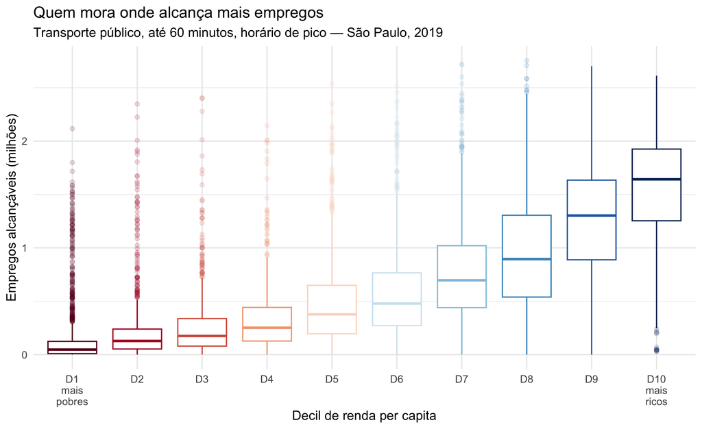

Figura 1: Empregos alcançáveis em até 60 minutos por transporte público, no pico, segundo o decil de renda do hexágono. São Paulo, 2019.

```r
grafico_decis <- base_analise[ano == 2019L & !is.na(decil_renda)]

ggplot(grafico_decis, aes(x = factor(decil_renda), y = empregos_60min / 1e6)) +
  geom_boxplot(aes(color = factor(decil_renda)), outlier.alpha = 0.15) +
  scale_color_brewer(palette = "RdBu", guide = "none") +
  scale_x_discrete(labels = c("D1\nmais\npobres", paste0("D", 2:9),
                              "D10\nmais\nricos")) +
  labs(
    x = "Decil de renda per capita",
    y = "Empregos alcançáveis (milhões)",
    title = "Quem mora onde alcança mais empregos",
    subtitle = "Transporte público, até 60 minutos, horário de pico — São Paulo, 2019"
  ) +
  theme_minimal(base_size = 12)
```

```r
razao <- grafico_decis[
  , .(media = weighted.mean(empregos_60min, w = pop_total, na.rm = TRUE)),
  by = decil_renda][order(decil_renda)]

cat(sprintf(
  "Decil 10 alcança em média %s empregos; decil 1 alcança %s.\nRazão: %.1f vezes.\n",
  format(round(razao[decil_renda == 10, media]), big.mark = "."),
  format(round(razao[decil_renda == 1, media]), big.mark = "."),
  razao[decil_renda == 10, media] / razao[decil_renda == 1, media]
))
```

```
#> Decil 10 alcança em média 1.649.723 empregos; decil 1 alcança 169.771.
#> Razão: 9.7 vezes.
```

O padrão do livro se reproduz: a acessibilidade cresce de forma sistemática com a renda. O Capítulo 3 explica o mecanismo — os mais ricos moram perto das concentrações de emprego e da oferta de transporte de média e alta capacidade; os mais pobres moram longe de ambas.

## 8.2 Tempo até o hospital mais próximo, por decil de renda

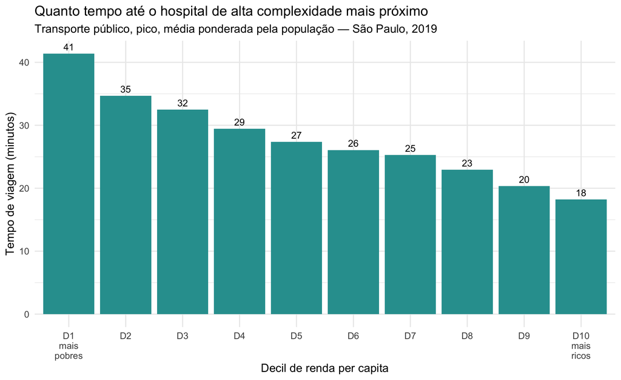

Figura 2: Tempo médio de viagem por transporte público até o estabelecimento de saúde de alta complexidade mais próximo, por decil de renda. São Paulo, 2019.

```r
hospital <- base_analise[ano == 2019L & !is.na(decil_renda)]
# Tratamento do livro: não alcançável em 2h passa a contar como 120 min
hospital[is.na(tempo_saude_alta_compl), tempo_saude_alta_compl := 120]

resumo_hospital <- hospital[
  , .(minutos = weighted.mean(tempo_saude_alta_compl, w = pop_total, na.rm = TRUE)),
  by = decil_renda][order(decil_renda)][!is.na(minutos)]

ggplot(resumo_hospital, aes(x = factor(decil_renda), y = minutos)) +
  geom_col(fill = "#2c9e9e") +
  geom_text(aes(label = round(minutos)), vjust = -0.5, size = 3.5) +
  scale_x_discrete(labels = c("D1\nmais\npobres", paste0("D", 2:9),
                              "D10\nmais\nricos")) +
  labs(
    x = "Decil de renda per capita",
    y = "Tempo de viagem (minutos)",
    title = "Quanto tempo até o hospital de alta complexidade mais próximo",
    subtitle = "Transporte público, pico, média ponderada pela população — São Paulo, 2019"
  ) +
  theme_minimal(base_size = 12)
```

## 8.3 Evolução no tempo, por decil de renda

Esta é a análise que só a série 2017–2019 permite, e é o motivo de a comparabilidade temporal ter sido tratada com tanto cuidado nas seções anteriores.

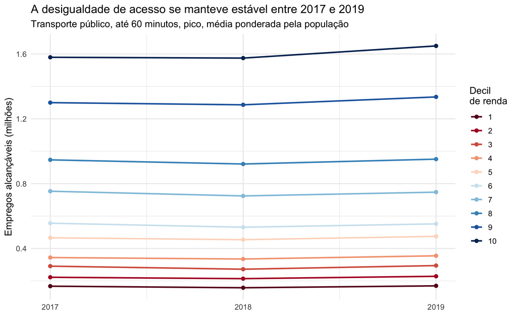

Figura 3: Evolução dos empregos alcançáveis em até 60 minutos por transporte público, por decil de renda. São Paulo, 2017–2019.

```r
evolucao <- base_analise[!is.na(decil_renda),
  .(empregos = weighted.mean(empregos_60min, w = pop_total, na.rm = TRUE)),
  by = .(ano, decil_renda)]

ggplot(evolucao, aes(x = ano, y = empregos / 1e6,
                     color = factor(decil_renda), group = decil_renda)) +
  geom_line(linewidth = 0.9) +
  geom_point(size = 1.8) +
  scale_color_brewer(palette = "RdBu", name = "Decil\nde renda") +
  scale_x_continuous(breaks = ANOS) +
  labs(
    x = NULL,
    y = "Empregos alcançáveis (milhões)",
    title = "A desigualdade de acesso se manteve estável entre 2017 e 2019",
    subtitle = "Transporte público, até 60 minutos, pico, média ponderada pela população"
  ) +
  theme_minimal(base_size = 12)
```

## 8.4 Comparação entre modos

Os cortes de 15, 30 e 60 minutos existem em todos os modos, o que permite compará-los diretamente. Reproduz o espírito da última análise do Capítulo 9, que contrasta automóvel e caminhada.

```r
comparacao_modos <- merge(
  acesso[ano == 2019L & periodo %in% c("pico", "nao_se_aplica")],
  socio[ano == 2019L, .(id_hex, ano, pop_total)],
  by = c("id_hex", "ano")
)[, .(empregos = weighted.mean(empregos_30min, w = pop_total, na.rm = TRUE)),
  by = modo][order(-empregos)]

comparacao_modos[, razao_vs_caminhada := round(
  empregos / empregos[modo == "caminhada"], 1)]
comparacao_modos
```

| modo | empregos | razao_vs_caminhada |
| --- | --- | --- |
| automovel | 850677.02 | 54.1 |
| bicicleta | 68546.79 | 4.4 |
| transporte_publico | 64018.89 | 4.1 |
| caminhada | 15726.16 | 1.0 |

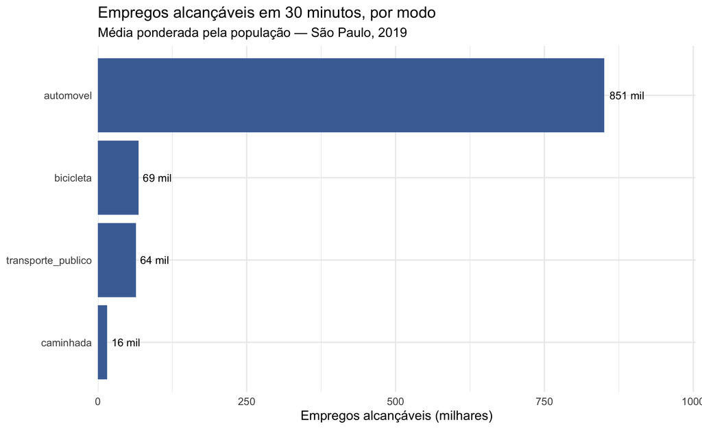

Figura 5: Empregos alcançáveis em até 30 minutos por modo de transporte, média ponderada pela população. São Paulo, 2019.

```r
ggplot(comparacao_modos, aes(x = reorder(modo, empregos), y = empregos / 1e3)) +
  geom_col(fill = "#4a6fa5") +
  geom_text(aes(label = paste0(round(empregos / 1e3), " mil")),
            hjust = -0.15, size = 3.5) +
  coord_flip() +
  scale_y_continuous(expand = expansion(mult = c(0, 0.18))) +
  labs(
    x = NULL, y = "Empregos alcançáveis (milhares)",
    title = "Empregos alcançáveis em 30 minutos, por modo",
    subtitle = "Média ponderada pela população — São Paulo, 2019"
  ) +
  theme_minimal(base_size = 12)
```

### 8.4.1 A checagem mais forte que temos

Este número em particular permite uma verificação externa. O Capítulo 9 do livro publica o resultado exato dessa razão para São Paulo:

> *“Em São Paulo e em Brasília, viagens de automóvel de até trinta minutos permitem acessar, em média, um número de empregos 54 vezes maior do que viagens a pé de mesma duração.”*

Se a nossa base foi construída corretamente, ela tem de reproduzir esse 54.

```r
razao_calculada <- comparacao_modos[modo == "automovel", razao_vs_caminhada]
razao_livro <- 54

cat(sprintf("Razão automóvel / caminhada nesta base: %.1f vezes\n",
            razao_calculada))
```

```
#> Razão automóvel / caminhada nesta base: 54.1 vezes
```

```r
cat(sprintf("Razão publicada no Capítulo 9 do livro: %d vezes\n", razao_livro))
```

```
#> Razão publicada no Capítulo 9 do livro: 54 vezes
```

```r
stopifnot(
  "A razão automóvel/caminhada não reproduz o valor publicado no livro" =
    abs(razao_calculada - razao_livro) < 1
)
cat("\nA base reproduz o valor publicado pelo Ipea.\n")
```

```
#>
#> A base reproduz o valor publicado pelo Ipea.
```

Esta é a validação mais forte do notebook. As checagens anteriores confirmam que a base é *internamente* consistente; esta confirma que ela concorda com um resultado publicado e independente. Se houvesse erro na seleção de colunas, na ponderação ou nos tipos, este número não fecharia.

## 8.5 Distribuição espacial

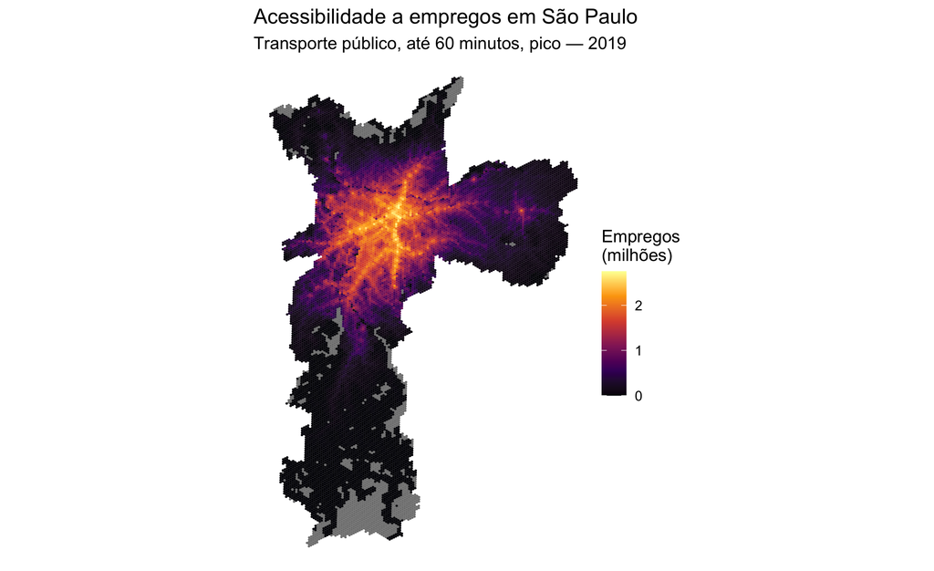

Figura 6: Distribuição espacial dos empregos alcançáveis em até 60 minutos por transporte público no pico. São Paulo, 2019.

```r
mapa <- merge(
  grade,
  acesso[ano == 2019L & modo == "transporte_publico" & periodo == "pico",
         .(id_hex, empregos_60min)],
  by = "id_hex"
)

ggplot(mapa) +
  geom_sf(aes(fill = empregos_60min / 1e6), color = NA) +
  scale_fill_viridis_c(option = "inferno", name = "Empregos\n(milhões)") +
  labs(
    title = "Acessibilidade a empregos em São Paulo",
    subtitle = "Transporte público, até 60 minutos, pico — 2019"
  ) +
  theme_void(base_size = 12)
```

O mapa mostra a concentração no vetor sudoeste e ao longo dos corredores de metrô e trem, com queda acentuada nas extremidades leste, sul e norte — o mesmo padrão descrito no Capítulo 3.

# 9 A planilha final

## 9.1 Montagem: uma tabela, pronta para uso

Até aqui trabalhamos com duas tabelas separadas — o que é a forma correta de *armazenar* os dados, sem repetir população e renda em cada modo de transporte. Mas quem vai analisar quer abrir **um arquivo** e começar. Então unimos as duas pela chave `id_hex` + `ano`.

```r
planilha <- merge(acesso, socio, by = c("id_hex", "ano"))

cat(sprintf("Após a união: %s linhas × %d colunas\n",
            format(nrow(planilha), big.mark = "."), ncol(planilha)))
```

```
#> Após a união: 210.826 linhas × 69 colunas
```

## 9.2 Remoção das células vazias da grade

A grade H3 é um retângulo de hexágonos que cobre o município inteiro, e parte dela cai em área sem nada: sem moradores e sem nenhuma oportunidade. Essas células só ocupam espaço no arquivo.

Duas armadilhas aqui, e as duas são do tipo que passa despercebido.

A primeira: um filtro mal feito descarta dado de verdade. Então medimos o que sai antes de remover, e exigimos que a perda seja exatamente zero.

A segunda, mais sutil: as oportunidades variam por ano. Se filtrássemos **linha por linha**, um hexágono que ganhou uma escola em 2019 entraria só naquele ano, e o painel deixaria de ser balanceado — a base perderia a comparabilidade temporal que a Seção 7.6 acabou de validar. Por isso o filtro decide por **hexágono**: uma célula fica se tiver conteúdo em *qualquer* ano, e então todos os seus anos ficam.

```r
tem_conteudo <- quote(
  pop_total > 0 | empregos_total > 0 | escolas_total > 0 |
    saude_total > 0 | matriculas_total > 0 | cras_total > 0
)

# Decisão no nível do hexágono: basta ter conteúdo em um dos três anos
hex_com_conteudo <- unique(planilha[eval(tem_conteudo), id_hex])

# Quanto de cada grandeza existe antes e depois do filtro, num ano e modo fixos
# (para não contar a mesma população várias vezes)
referencia <- planilha[ano == 2019L & modo == "caminhada"]
mantidos   <- referencia[id_hex %chin% hex_com_conteudo]

conferencia <- data.table(
  grandeza = c("População", "Empregos", "Escolas", "Matrículas",
               "Estab. de saúde", "CRAS"),
  total_na_grade = c(
    referencia[, sum(pop_total, na.rm = TRUE)],
    referencia[, sum(empregos_total, na.rm = TRUE)],
    referencia[, sum(escolas_total, na.rm = TRUE)],
    referencia[, sum(matriculas_total, na.rm = TRUE)],
    referencia[, sum(saude_total, na.rm = TRUE)],
    referencia[, sum(cras_total, na.rm = TRUE)]
  ),
  total_apos_filtro = c(
    mantidos[, sum(pop_total, na.rm = TRUE)],
    mantidos[, sum(empregos_total, na.rm = TRUE)],
    mantidos[, sum(escolas_total, na.rm = TRUE)],
    mantidos[, sum(matriculas_total, na.rm = TRUE)],
    mantidos[, sum(saude_total, na.rm = TRUE)],
    mantidos[, sum(cras_total, na.rm = TRUE)]
  )
)
conferencia[, perdido := total_na_grade - total_apos_filtro]
conferencia
```

| grandeza | total_na_grade | total_apos_filtro | perdido |
| --- | --- | --- | --- |
| População | 11163678 | 11163678 | 0 |
| Empregos | 3461972 | 3461972 | 0 |
| Escolas | 2632 | 2632 | 0 |
| Matrículas | 1621803 | 1621803 | 0 |
| Estab. de saúde | 885 | 885 | 0 |
| CRAS | 55 | 55 | 0 |

```r
stopifnot(
  "O filtro da grade descartou conteúdo — não pode" =
    all(conferencia$perdido == 0)
)

hex_antes <- uniqueN(planilha$id_hex)
planilha <- planilha[id_hex %chin% hex_com_conteudo]
hex_depois <- uniqueN(planilha$id_hex)

cat(sprintf(
  "\nHexágonos: %s → %s (removidos %s, sem população e sem oportunidades em nenhum ano).\n",
  format(hex_antes, big.mark = "."), format(hex_depois, big.mark = "."),
  format(hex_antes - hex_depois, big.mark = ".")
))
```

```
#>
#> Hexágonos: 15.059 → 10.056 (removidos 5.003, sem população e sem oportunidades em nenhum ano).
```

```r
# O painel tem de continuar balanceado: mesmo conjunto de hexágonos em cada ano
por_ano <- planilha[modo == "caminhada", .(hexagonos = uniqueN(id_hex)), by = ano]
por_ano
```

| ano | hexagonos |
| --- | --- |
| 2017 | 10056 |
| 2018 | 10056 |
| 2019 | 10056 |

```r
stopifnot(
  "O filtro desbalanceou o painel entre os anos" =
    uniqueN(por_ano$hexagonos) == 1L
)

cat(sprintf("Planilha final: %s linhas × %d colunas.\n",
            format(nrow(planilha), big.mark = "."), ncol(planilha)))
```

```
#> Planilha final: 140.784 linhas × 69 colunas.
```

Perda zero nas seis grandezas, e o painel segue balanceado. As células removidas eram grade vazia, não periferia — distinção que importa, porque foi justamente descartar a periferia que invalidou tentativas anteriores.

## 9.3 Ordenação das colunas

Colunas agrupadas por assunto, para quem abrir o arquivo numa planilha conseguir se orientar.

```r
ordem <- c(
  # Identificação
  "id_hex", "ano", "modo", "periodo", "lon", "lat", "name_muni", "code_muni",
  # Quem mora aqui (Censo 2010)
  "pop_total", "pop_homens", "pop_mulheres",
  "pop_branca", "pop_negra", "pop_indigena", "pop_amarela",
  "pop_00a05", "pop_06a14", "pop_15a18", "pop_19a24", "pop_25a39",
  "pop_40a69", "pop_70mais",
  "renda_per_capita", "quintil_renda", "decil_renda",
  # O que existe aqui (uso do solo, varia por ano)
  "empregos_total", "empregos_baixa_esc", "empregos_media_esc", "empregos_alta_esc",
  "escolas_total", "escolas_infantil", "escolas_fundamental", "escolas_medio",
  "matriculas_total", "matriculas_infantil", "matriculas_fundamental",
  "matriculas_medio",
  "saude_total", "saude_baixa_compl", "saude_media_compl", "saude_alta_compl",
  "cras_total",
  # O que se alcança daqui (varia por modo e período)
  "empregos_15min", "empregos_30min", "empregos_45min", "empregos_60min",
  "empregos_90min", "empregos_120min",
  "empregos_baixa_esc_60min", "empregos_media_esc_60min", "empregos_alta_esc_60min",
  "saude_30min", "saude_60min", "escolas_30min", "escolas_60min",
  "matriculas_30min", "matriculas_60min", "cras_30min", "cras_60min",
  "tempo_saude_qualquer", "tempo_saude_baixa_compl", "tempo_saude_media_compl",
  "tempo_saude_alta_compl", "tempo_escola_qualquer", "tempo_escola_infantil",
  "tempo_escola_fundamental", "tempo_escola_medio", "tempo_cras",
  "pessoas_que_alcancam_60min"
)

stopifnot(
  "A ordenação não cobre exatamente as colunas da planilha" =
    setequal(ordem, names(planilha))
)

setcolorder(planilha, ordem)
setorder(planilha, id_hex, ano, modo, periodo)
```

## 9.4 Dicionário de variáveis

O dicionário é conferido contra as colunas reais da planilha por asserção, o que impede que ele fique dessincronizado da base.

```r
dicionario <- rbindlist(list(
  data.table(
    grupo = "identificacao",
    coluna = c("id_hex", "ano", "modo", "periodo", "lon", "lat",
               "name_muni", "code_muni"),
    codigo_aop = c("id_hex", "year", "mode", "peak", "—", "—",
                   "name_muni", "code_muni"),
    descricao = c(
      "Identificador único da célula da grade hexagonal H3",
      "Ano de referência das oportunidades e da acessibilidade: 2017, 2018 ou 2019",
      "Modo de transporte: transporte_publico, caminhada, bicicleta ou automovel",
      "Período do dia: pico (6h-8h), fora_pico (14h-16h) ou nao_se_aplica (modos ativos)",
      "Longitude do centroide do hexágono, em WGS 84",
      "Latitude do centroide do hexágono, em WGS 84",
      "Nome do município",
      "Código IBGE de sete dígitos do município")),
  data.table(
    grupo = "populacao_censo_2010",
    coluna = c("pop_total", "pop_homens", "pop_mulheres", "pop_branca",
               "pop_negra", "pop_indigena", "pop_amarela", "pop_00a05",
               "pop_06a14", "pop_15a18", "pop_19a24", "pop_25a39",
               "pop_40a69", "pop_70mais"),
    codigo_aop = c("P001", "P007", "P006", "P002", "P003", "P004", "P005",
                   "P010", "P011", "P012", "P013", "P014", "P015", "P016"),
    descricao = c(
      "População total residente no hexágono. USE COMO PESO nas médias",
      "Homens. Vem de P007 — o dicionário do {aopdata} troca P006 e P007; ver secao 'O rotulo de sexo esta correto?' no notebook",
      "Mulheres. Vem de P006 — idem",
      "População branca", "População negra",
      "População indígena", "População amarela",
      "Pessoas de 0 a 5 anos", "Pessoas de 6 a 14 anos",
      "Pessoas de 15 a 18 anos", "Pessoas de 19 a 24 anos",
      "Pessoas de 25 a 39 anos", "Pessoas de 40 a 69 anos",
      "Pessoas de 70 anos ou mais")),
  data.table(
    grupo = "renda_censo_2010",
    coluna = c("renda_per_capita", "quintil_renda", "decil_renda"),
    codigo_aop = c("R001", "R002", "R003"),
    descricao = c(
      "Renda per capita média do hexágono, em R$ de 2010",
      "Quintil de renda: 1 = mais pobres, 5 = mais ricos. Vazio se não há moradores",
      "Decil de renda: 1 = mais pobres, 10 = mais ricos. Vazio se não há moradores")),
  data.table(
    grupo = "uso_do_solo_no_hexagono",
    coluna = c("empregos_total", "empregos_baixa_esc", "empregos_media_esc",
               "empregos_alta_esc", "escolas_total", "escolas_infantil",
               "escolas_fundamental", "escolas_medio", "matriculas_total",
               "matriculas_infantil", "matriculas_fundamental",
               "matriculas_medio", "saude_total", "saude_baixa_compl",
               "saude_media_compl", "saude_alta_compl", "cras_total"),
    codigo_aop = c("T001", "T002", "T003", "T004", "E001", "E002", "E003",
                   "E004", "M001", "M002", "M003", "M004", "S001", "S002",
                   "S003", "S004", "C001"),
    descricao = c(
      "Empregos localizados NESTE hexágono",
      "Empregos que exigem baixa escolaridade",
      "Empregos que exigem média escolaridade",
      "Empregos que exigem alta escolaridade",
      "Escolas públicas neste hexágono",
      "Escolas públicas de ensino infantil",
      "Escolas públicas de ensino fundamental",
      "Escolas públicas de ensino médio",
      "Matrículas em escolas públicas",
      "Matrículas no ensino infantil",
      "Matrículas no ensino fundamental",
      "Matrículas no ensino médio",
      "Estabelecimentos de saúde neste hexágono",
      "Estabelecimentos de saúde de baixa complexidade",
      "Estabelecimentos de saúde de média complexidade",
      "Estabelecimentos de saúde de alta complexidade",
      "CRAS — Centros de Referência de Assistência Social")),
  data.table(
    grupo = "acessibilidade_empregos",
    coluna = c("empregos_15min", "empregos_30min", "empregos_45min",
               "empregos_60min", "empregos_90min", "empregos_120min",
               "empregos_baixa_esc_60min", "empregos_media_esc_60min",
               "empregos_alta_esc_60min"),
    codigo_aop = c("CMATT15", "CMATT30", "CMATT45", "CMATT60", "CMATT90",
                   "CMATT120", "CMATB60", "CMATM60", "CMATA60"),
    descricao = c(
      "Empregos ALCANÇÁVEIS a partir daqui em até 15 minutos",
      "Empregos alcançáveis em até 30 minutos",
      "Empregos alcançáveis em até 45 minutos. Só caminhada e bicicleta têm este corte",
      "Empregos alcançáveis em até 60 minutos",
      "Empregos alcançáveis em até 90 minutos. Só transporte público e automóvel",
      "Empregos alcançáveis em até 120 minutos. Só transporte público e automóvel",
      "Empregos de baixa escolaridade alcançáveis em até 60 minutos",
      "Empregos de média escolaridade alcançáveis em até 60 minutos",
      "Empregos de alta escolaridade alcançáveis em até 60 minutos")),
  data.table(
    grupo = "acessibilidade_servicos",
    coluna = c("saude_30min", "saude_60min", "escolas_30min", "escolas_60min",
               "matriculas_30min", "matriculas_60min", "cras_30min",
               "cras_60min", "pessoas_que_alcancam_60min"),
    codigo_aop = c("CMAST30", "CMAST60", "CMAET30", "CMAET60", "CMAMT30",
                   "CMAMT60", "CMACT30", "CMACT60", "CMPPT60"),
    descricao = c(
      "Estabelecimentos de saúde alcançáveis em até 30 minutos",
      "Estabelecimentos de saúde alcançáveis em até 60 minutos",
      "Escolas públicas alcançáveis em até 30 minutos",
      "Escolas públicas alcançáveis em até 60 minutos",
      "Matrículas públicas alcançáveis em até 30 minutos",
      "Matrículas públicas alcançáveis em até 60 minutos",
      "CRAS alcançáveis em até 30 minutos",
      "CRAS alcançáveis em até 60 minutos",
      "Acessibilidade passiva: pessoas que alcançam ESTE hexágono em até 60 min")),
  data.table(
    grupo = "tempo_ate_o_mais_proximo",
    coluna = c("tempo_saude_qualquer", "tempo_saude_baixa_compl",
               "tempo_saude_media_compl", "tempo_saude_alta_compl",
               "tempo_escola_qualquer", "tempo_escola_infantil",
               "tempo_escola_fundamental", "tempo_escola_medio", "tempo_cras"),
    codigo_aop = c("TMIST", "TMISB", "TMISM", "TMISA", "TMIET", "TMIEI",
                   "TMIEF", "TMIEM", "TMICT"),
    descricao = paste(
      c("Minutos até o estabelecimento de saúde mais próximo",
        "Minutos até a saúde de baixa complexidade mais próxima",
        "Minutos até a saúde de média complexidade mais próxima",
        "Minutos até a saúde de alta complexidade mais próxima",
        "Minutos até a escola pública mais próxima",
        "Minutos até a escola de ensino infantil mais próxima",
        "Minutos até a escola de ensino fundamental mais próxima",
        "Minutos até a escola de ensino médio mais próxima",
        "Minutos até o CRAS mais próximo"),
      "— VAZIO significa NÃO ALCANÇÁVEL no limite de roteamento, não dado faltante"))
))

stopifnot(
  "O dicionário e a planilha divergem" =
    setequal(dicionario$coluna, names(planilha))
)

# Reordena o dicionário na mesma ordem das colunas da planilha
dicionario <- dicionario[match(names(planilha), coluna)]
dicionario[, posicao := .I]
setcolorder(dicionario, c("posicao", "coluna", "grupo", "codigo_aop", "descricao"))

cat(sprintf("Dicionário conferido: %d variáveis, uma para cada coluna.\n",
            nrow(dicionario)))
```

```
#> Dicionário conferido: 69 variáveis, uma para cada coluna.
```

```r
dicionario[, .N, by = grupo]
```

| grupo | N |
| --- | --- |
| identificacao | 8 |
| populacao_censo_2010 | 14 |
| renda_censo_2010 | 3 |
| uso_do_solo_no_hexagono | 17 |
| acessibilidade_empregos | 9 |
| acessibilidade_servicos | 9 |
| tempo_ate_o_mais_proximo | 9 |

## 9.5 Gravação

```r
arquivo_planilha   <- file.path(DIR_SAIDA, "acessibilidade_sp_2017_2019.csv")
arquivo_dicionario <- file.path(DIR_SAIDA, "dicionario_variaveis.csv")
arquivo_grade      <- file.path(DIR_SAIDA, "grade_hexagonos_sp.gpkg")

fwrite(planilha, arquivo_planilha, na = "", dec = ".", bom = TRUE)
fwrite(dicionario, arquivo_dicionario, na = "", dec = ".", bom = TRUE)

# Só os hexágonos que ficaram na planilha
st_write(grade[grade$id_hex %in% unique(planilha$id_hex), "id_hex"],
         arquivo_grade, delete_dsn = TRUE, quiet = TRUE)

tamanho <- function(f) {
  format(structure(file.size(f), class = "object_size"),
         units = "auto", standard = "SI")
}

data.table(
  arquivo = basename(c(arquivo_planilha, arquivo_dicionario, arquivo_grade)),
  linhas = c(nrow(planilha), nrow(dicionario),
             uniqueN(planilha$id_hex)),
  colunas = c(ncol(planilha), ncol(dicionario), 2L),
  tamanho = sapply(c(arquivo_planilha, arquivo_dicionario, arquivo_grade),
                   tamanho, USE.NAMES = FALSE)
)
```

| arquivo | linhas | colunas | tamanho |
| --- | --- | --- | --- |
| acessibilidade_sp_2017_2019.csv | 140784 | 69 | 42.9 MB |
| dicionario_variaveis.csv | 69 | 5 | 7.3 kB |
| grade_hexagonos_sp.gpkg | 10056 | 2 | 2.6 MB |

O `bom = TRUE` grava a marca de codificação UTF-8 que o Excel espera. Sem ela, os acentos aparecem corrompidos ao abrir o CSV no Windows.

## 9.6 O que é cada arquivo

Tabela 7: Os três arquivos gerados, em dados/saida/.

Os três arquivos gerados, em dados/saida/.

| Arquivo | É isto | Uma linha é |
| --- | --- | --- |
| `acessibilidade_sp_2017_2019.csv` | **A planilha.** É o arquivo para analisar | hexágono × ano × modo × período |
| `dicionario_variaveis.csv` | O significado de cada uma das colunas da planilha | uma variável |
| `grade_hexagonos_sp.gpkg` | A geometria dos hexágonos, para fazer mapas | um hexágono |

## 9.7 A estrutura da planilha, em uma frase

Cada linha responde: **“a partir deste hexágono, neste ano, por este modo e neste horário — quem mora aqui, o que existe aqui, e o que se alcança daqui.”**

As colunas se dividem em três blocos com significados bem diferentes, e confundi-los é o erro mais fácil de cometer:

Tabela 8: Os três blocos de colunas. `empregos_total` e `empregos_60min` medem coisas distintas.

Os três blocos de colunas. `empregos_total` e `empregos_60min` medem coisas distintas.

| Bloco | Responde | Varia com | Exemplo |
| --- | --- | --- | --- |
| `pop_*`, `renda_*` | Quem mora **aqui** | Nada — é o Censo 2010, igual nos três anos | `pop_total` = 2.386 moradores |
| `empregos_total`, `escolas_total`, … | O que existe **aqui** | O ano | `empregos_total` = 52 empregos neste hexágono |
| `empregos_60min`, `tempo_saude_*`, … | O que se alcança **daqui** | O ano, o modo e o período | `empregos_60min` = 1,2 milhão de empregos ao alcance |

## 9.8 Como carregar

Ler o CSV diretamente com `fread()` reintroduz a armadilha da Seção 6.3: um arquivo de texto não guarda tipo, e o `fread()` vai inferir inteiro outra vez. O projeto acompanha um carregador que resolve isso:

```r
source("R/carregar_base.R")

base <- carregar_base()                                   # tudo
tp   <- carregar_base(modo = "transporte_publico",        # só um recorte
                      periodo = "pico")
```

Em Python o problema não existe, porque o pandas usa ponto flutuante de 64 bits:

```python
import pandas as pd
base = pd.read_csv("dados/saida/acessibilidade_sp_2017_2019.csv")
tp = base.query("modo == 'transporte_publico' and periodo == 'pico'")

# média ponderada pela população, como o livro exige
import numpy as np
np.average(tp.query("ano == 2019").empregos_60min,
           weights=tp.query("ano == 2019").pop_total)
```

# 10 Regras de uso da base

Sete pontos que decorrem da natureza da fonte e que evitam conclusões erradas.

**0. Carregue a base com `R/carregar_base.R`.** Ler os CSVs diretamente com `fread()` faz as contagens voltarem como inteiro e quebra silenciosamente qualquer média ponderada (Seção 6.3). É a primeira regra porque é a única que produz um erro invisível.

**1. Sempre ponderar pela população.** Os indicadores são atributos de *lugares*, não de pessoas. Um hexágono com 3 mil habitantes e outro com 30 não podem pesar igual numa média sobre a população. Use `weighted.mean(x, w = pop_total)`, como o livro faz em todos os exemplos.

**2. População e renda são de 2010; oportunidades são do ano da linha.** O AOP publica dados populacionais de um único censo. Portanto `pop_total`, `renda_per_capita` e `decil_renda` são idênticos nos três anos, enquanto `empregos_total` e os demais de uso do solo variam. A variação da acessibilidade entre 2017 e 2019 reflete mudanças na rede de transporte e na distribuição de oportunidades — não mudanças demográficas.

**3. Comparar modos apenas nos cortes de 15, 30 e 60 minutos.** São os únicos presentes em todos os modos, conforme verificado na Seção 7.8. As colunas de 45 minutos só têm valor para caminhada e bicicleta; as de 90 e 120 minutos, só para transporte público e automóvel. Fora disso a célula está vazia porque o indicador não existe naquele modo, não por falha.

**4. Automóvel não tem série temporal.** Existe só para 2019. Use-o para comparar modos naquele ano, nunca para tendência.

**5. Célula vazia nas colunas `tempo_*` significa “não alcançável”.** Não é dado faltante. Se a análise exigir um número, o Capítulo 9 sugere imputar o limite de roteamento — mas esse limite **difere por modo**: 60 minutos para caminhada, 90 para bicicleta e acima de 175 para transporte público, que o AOP não trunca em 120. Automóvel não tem célula vazia. Os valores medidos estão na Seção 6, e imputar o número errado inventa viagens que o modelo não admite. Essa é uma decisão da análise, e precisa ser declarada.

**6. Confira rótulo contra conteúdo antes de confiar.** `pop_homens` e `pop_mulheres` vêm, respectivamente, de `P007` e `P006` — o inverso do que o dicionário oficial do `{aopdata}` documenta. A Seção 7.3 demonstra a inversão contra os números do Censo 2010 em três cidades. As colunas desta base estão nomeadas pelo conteúdo verificado; se você reler o dado direto do `{aopdata}`, o erro volta.

# Referência

Pereira, Rafael H. M. & Herszenhut, Daniel (2023). *Introdução à acessibilidade urbana: um guia prático em R*. Ipea — Instituto de Pesquisa Econômica Aplicada. https://ipeagit.github.io/intro_access_book/

Capítulos utilizados na construção desta base:

| Capítulo | O que foi usado |
| --- | --- |
| 2 — Medidas de acessibilidade | Definição formal dos indicadores cumulativo e de custo mínimo |
| 3 — Calculando acessibilidade em R | Caminho alternativo (r5r), e a exigência de ponderar pela população |
| 4 — Dados GTFS | Estrutura do feed e o papel do `calendar.txt` na validade temporal |
| 7 — Dados de população | Dicionário das variáveis `P*` e `R*` |
| 8 — Dados de oportunidades | Dicionário das variáveis `T*`, `E*`, `M*`, `S*`, `C*` |
| 9 — Estimativas de acessibilidade | `read_access()`, codificação `CMA`/`CMP`/`TMI` e análises de referência |

```
#> Gerado em: 03/09/2026 11:37
```

```
#> R: R version 4.6.0 (2026-04-24)
```

```
#> aopdata: 1.1.2
```